# GCDS: Data Visualization and the Grammar of Graphics

## *`geom_density()`*

When you need a smoothed version of the histogram, `geom_density()` will produce a kernel density plot. In this case, we also add `fill = cyl` to fill the densities by color.

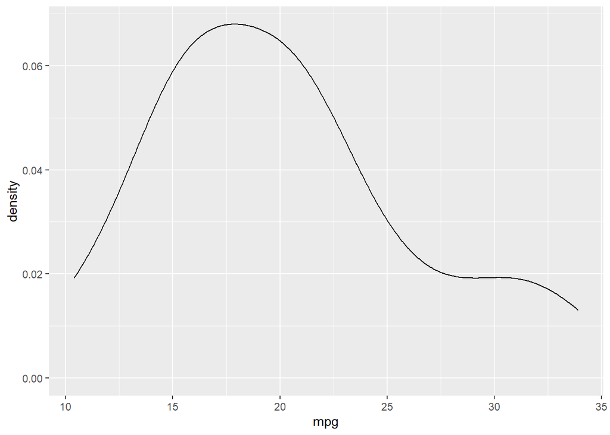

```r
ggplot(data = mtcars,
       mapping = aes(x = mpg)) +
  geom_density(mapping = aes(fill = cyl),
               alpha = .5)
```

Wait, huh? But this does not fill the densities with a color corresponding to `cyl`. Does it need to be a different type?

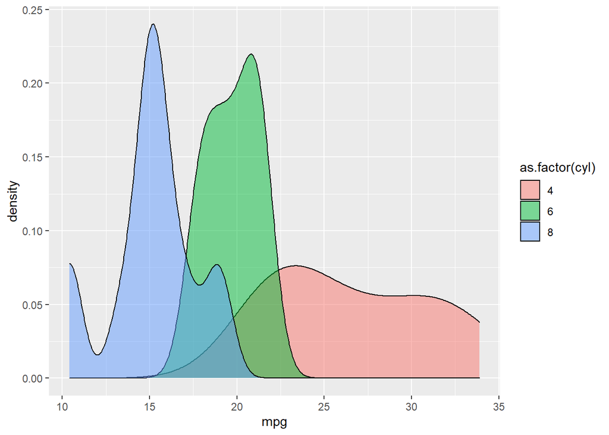

```r
ggplot(data = mtcars,
       mapping = aes(x = mpg)) +
  geom_density(mapping = aes(fill = as.factor(cyl)),
               alpha = .5)
```

OK better, except for cleaning up the legend.

# **Bar Chart Varieties**

There are two types of bar chart geometry functions: `geom_bar()` and `geom_col()`. `geom_bar()` takes either an `x` or a `y` (not both) and produces a plot for which the height of the bar is proportional to the count/frequency of cases in the vector. By contrast, `geom_col()` takes both an `x` and a `y` and plots the height of each x variable bar relative to the value of the y variable. If you want the heights of the bars to represent values in the data, use `geom_col()`

## *`geom_bar()`*

There are times you want bar plots.

Trying out `geom_bar()`, we need an either an `x` or a `y` aesthetic mapping but not both. When passing a variable to x, the bar will be vertical and when passing the variable to y, the bar will be horizontal. Because the mapping is inherited from `ggplot()`, you’ll throw an error like the following because both x and y will be inherited:

`Error in f():` `! stat_count() can only have an x or y aesthetic.`

We can change the mapping in the base `ggplot()` layer, which will plot bars corresponding to the unique levels of the variable passed to `x` at a height relative to the frequency of occurrence of those unique levels. To see what might be plotted from `A`, see `DATA$A` 1, 2, 3, 4.

Checking `?geom_bar`, you will notice that `geom_bar()` has a default `stat = "count"`. This means that the default bar plot will plot the `"count"`, or frequency of elements in a vector variable. When the count or frequency of a value is 1, the bar height will be 1 on the y axis and if an element appears 5 times in the vector, the bar height will be 5. For a horizontal bar, the bar length, rather than height, will be 5. Looking at `DATA$A` 1, 2, 3, 4, what might you expect the bar to look like?

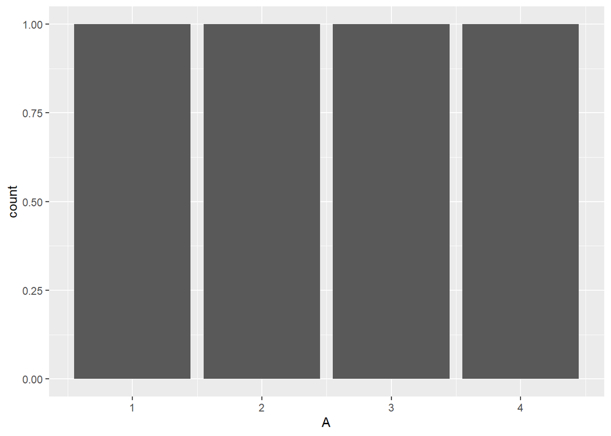

```r
# setting x
DATA %>%
  ggplot(., aes(x = A)) +
  geom_bar()
```

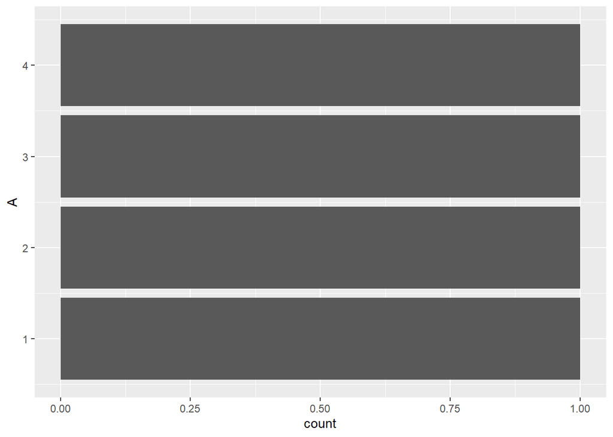

```r
# setting y
DATA %>%
  ggplot(., aes(y = A)) +
  geom_bar()
```

If the aesthetics are mapped and inherited, you can still create a plot that accounts for both `x` and `y` variables. Passing `stat = "identity"` to `geom_bar()` will produce a bar plot that presents the value of `y` in the data frame (its identity) for each value of `x`.

When passing, pay attention to which variables are inherited by both `x` and `y` as they will likely produce very different plots.

```r
DATA %>%
  ggplot(., aes(x = A, y = B)) +
  geom_bar(stat = "identity")
```

[output not shown]

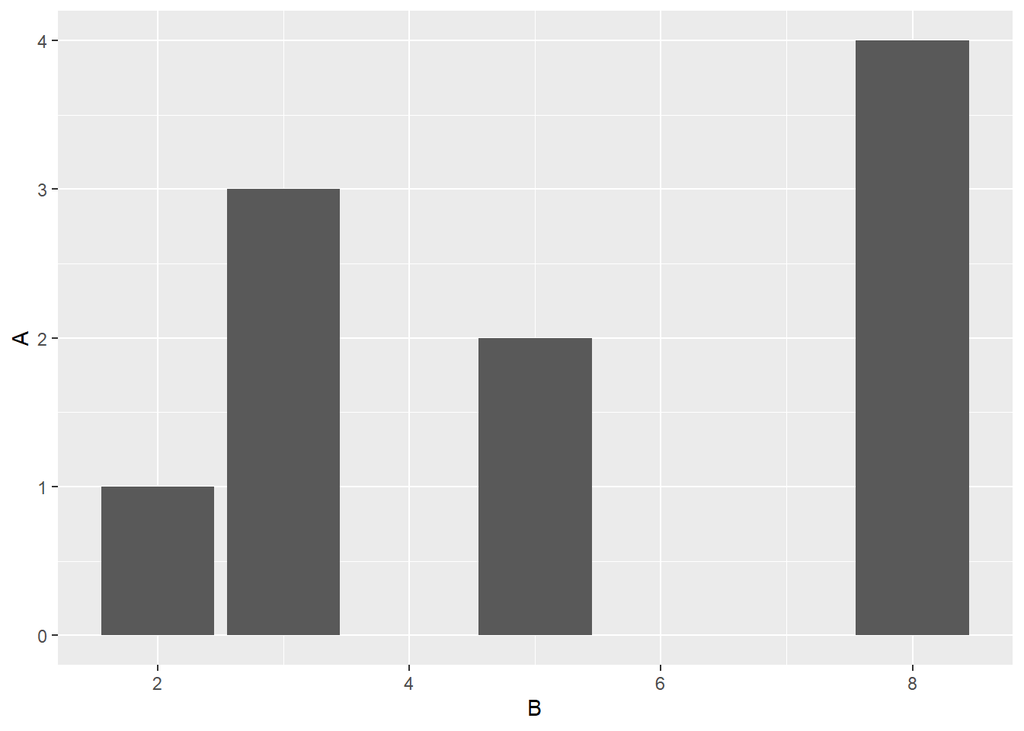

```r
DATA %>%
  ggplot(., aes(x = B, y = A)) +
  geom_bar(stat = "identity")
```

By default, the scale for x and y are continuous (see above). If you don’t like the fact that bars take positions for which there are no labels and that labels are where no bars are, convert `B` it to a factor.

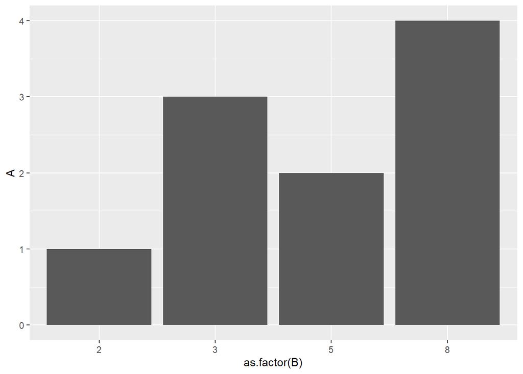

```r
DATA %>%
  ggplot(., aes(x = as.factor(B), y = A)) +
  geom_bar(stat = "identity")
```

## *`geom_col()`*

`geom_bar(stat = "identity")` is actually the same as another plot. A column plot using `geom_col()`. We need both `x` and `y` variables and when specified, the columns will plotted for each unique level of `x` at a height corresponding to the value of `y`. One way to think about `geom_col()` is that it plots columns at the same location as the points in `geom_point()`.

```r
DATA %>%
  select(., c("A", "B"))
```

```
##   A B
## 1 1 2
## 2 2 5
## 3 3 3
## 4 4 8
```

```r
DATA %>%
  ggplot(., aes(x = A, y = B)) +
  geom_col()
```

[output not shown]

```r
DATA %>%
  ggplot(., aes(x = A, y = B)) +
  geom_col()
```

[output not shown]

If your x axis (or y axis) is categorical/discrete rather than continuous.

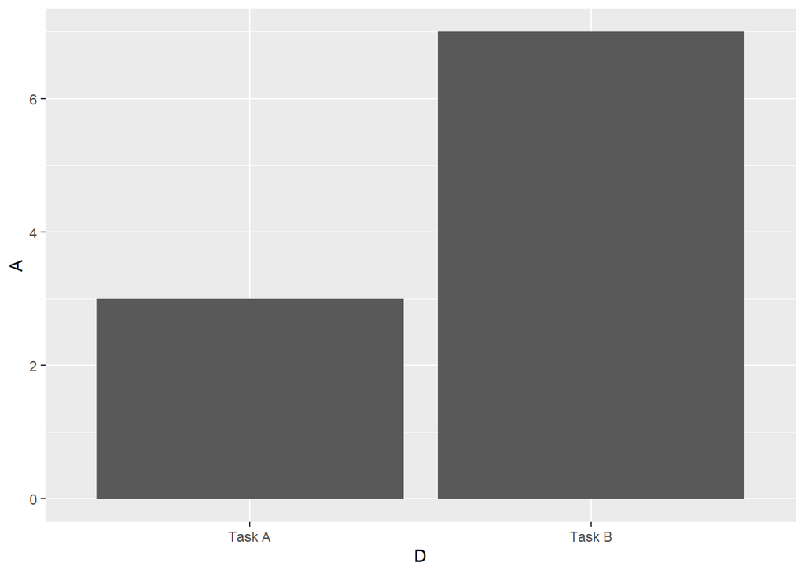

```r
DATA %>%
  ggplot(., aes(x = D, y = A)) +
  geom_col()
```

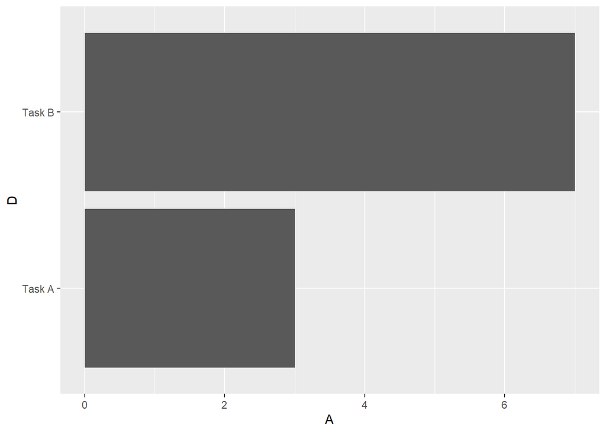

```r
DATA %>%
  ggplot(., aes(x = A, y = D)) +
  geom_col()
```